# time-varying N-body simulation

```python
#importing the usual libraries
import numpy as np

import matplotlib.pyplot as plt
```

## 1 code from homework D Net Forces vectors

I copied this code from the solution, as I was not able to figure it out on my own in homework D

I am just copying and pasting the code from the homework D solutions below:

```python
au = 1.496e+11    # in meters

masses = [2.0e24, 30.0e24, 65.0e24, 40.0e24, 3.0e24]   # in kg

positions = [np.array([ 0.6,  2.5,  0.04])*au,
             np.array([ 0.9,  9.2,  0.12])*au,
             np.array([-4.3, -2.1,  0.85])*au,
             np.array([10.9,  3.2,  0.00])*au,
             np.array([-2.5, -1.6, -0.42])*au]
print(type(masses))
```

```
<class 'list'>
```

```python
# define the gravitational constant
G = 6.67e-11 # m**3 kg / s

def magnitude(a):
    '''
    This function returns the magnitude of a vector.

    Parmeters
    ---------
    a : numpy array
        An array representing a physical vector.
        It can have any number of elements,
        but 2 or 3 elements will be most common:
            in 2D, a = np.array([x, y])
            in 3D, a = np.array([x, y, z])

    Returns
    -------
    |a| : float
        The magnitude (length) of the array.
    '''

    return np.sqrt(np.sum(a**2))

def unit(a):
    '''
    This function returns a vector's unit vector
    (the vector that is parallel to it but has length of 1)

    Parmeters
    ---------
    a : numpy array
        An array representing a physical vector.
        It can have any number of elements,
        but 2 or 3 elements will be most common:
            in 2D, a = np.array([x, y])
            in 3D, a = np.array([x, y, z])

    Returns
    -------
    a_hat : float
        The unit vector parallel to the vector
    '''

    return a/magnitude(a)

def separation(p_i, p_j):
    '''
    This function returns the separation between two vectors.

    Parmeters
    ---------
    p_i : numpy array
        An array representing a physical vector.

    p_j : numpy array
        An array representing a second physical vector.

    Returns
    -------
    r_ij : numpy array
        The separation vector, p_j - p_i.
    '''

    return p_j - p_i

def force_magnitude(m_i, m_j, r):
    '''
    This function returns the magnitude of the
    gravitational force, given two masses
    and a separation.

    Parmeters
    ---------
    m_i : float
        A mass, in kg.

    m_j : float
        A mass, in kg.

    r : float
        The distance between the two masses, in kg.

    Returns
    -------
    F_g : float
        The magnitude of the force of gravity between them, in N.
    '''

    return (G*m_i*m_j)/(r**2)
```

```python
def forceVector(m_i, m_j, p_i, p_j):
    '''
    This function returns the full gravitational force vector
    for the force acting on particle i, caused by particle j.



    Parmeters
    ---------
    m_i : float
        A mass representing particle i, in kg.

    m_j : float
        A mass representing particle j, in kg.

    p_i : numpy array
        A vector representing the position of particle i.

    p_j : numpy array
        A vector representing the position of particle j.


    Returns
    -------
    F_g : numpy array
        The force vector acting on particle i, in N.
    '''

    # calculate the separation vector, and its magnitude
    r_vector = separation(p_i, p_j)
    r_magnitude = magnitude(r_vector)
    #print(f" the seperation is, {r_vector}")
    # calculate the magnitude of the force
    F_magnitude = force_magnitude(m_i, m_j, r_magnitude)

    # calculate the direction of the force, as a unit vector
    F_unit = unit(r_vector)

    # return the full force vector
    return F_magnitude * F_unit
```

```python
def netForces(masses, positions):
    """
    Compute net gravitational force vector exerted on
    particle i by all particles j, and do this for all i.

    Parameters
    ----------
    masses : list of floats
        Particle masses in kg.
    positions : list of numpy arrays
        Particle positions in cartesian coordinates in m.

    Returns
    -------
    netForces : list of numpy arrays
        Components of gravitational force vectors in N.

    Example
    -------
    >>> # forces between Earth and 70 kg person on surface
    >>> masses = [6e24,70]
    >>> radiusEarth = 6380000 # m
    >>> positions = [np.array([0, 0, 0])*radiusEarth, np.array([1, 1, 1])*radiusEarth]
    >>> netForces(masses,positions)
    [array([   0.        ,    0.        ,  688.23026503]),
     array([   0.        ,    0.        , -688.23026503])]

    """
    # empty force list
    force_list = []

    # for each body i
    for i in range(len(masses)):

        # zero net force vector; add to this for each j
        net_force_i = np.zeros(3)

        # vector sum all forces on i by bodies j
        for j in range(len(masses)):
            # omit self-interactions (body i on itself):
            if i != j:
                # vector sum of net force with additional force from body j
                net_force_i += forceVector(masses[i],masses[j],positions[i],positions[j])

        # add net force to force list:
        force_list.append(net_force_i)

    return force_list
```

```python
print(masses)
forces = netForces(masses,positions)
print(forces)
print(len(masses))
print(len(forces[0]))
accelerations = []


acceleration = []
print(f"\n")
for i in range(len(forces)):
    print(f"\n")

    local = []
    for j in range(len(forces[i])):
        print(f" i = {i} mass = {masses[i]} dimension ={forces[i][j]}")
        local.append(forces[i][j]/masses[i])

    acceleration.append(local)


print(acceleration)



#print(forces/masses)
```

```
[2e+24, 3e+25, 6.5e+25, 4e+25, 3e+24]
[array([-4.11343427e+15, -2.15614139e+15,  9.90522230e+14]), array([ 6.12126538e+15, -5.34319947e+16,  1.77549137e+15]), array([ 1.40608183e+17,  7.47025316e+16, -6.88057387e+16]), array([-5.45556893e+16,  2.97690767e+15,  1.79960353e+15]), array([-8.80603249e+16, -2.20913032e+16,  6.42401215e+16])]
5
3




 i = 0 mass = 2e+24 dimension =-4113434268164187.0
 i = 0 mass = 2e+24 dimension =-2156141386413789.0
 i = 0 mass = 2e+24 dimension =990522229545991.8


 i = 1 mass = 3e+25 dimension =6121265379904856.0
 i = 1 mass = 3e+25 dimension =-5.343199467396957e+16
 i = 1 mass = 3e+25 dimension =1775491372789684.8


 i = 2 mass = 6.5e+25 dimension =1.4060818300865992e+17
 i = 2 mass = 6.5e+25 dimension =7.470253163851154e+16
 i = 2 mass = 6.5e+25 dimension =-6.880573867309763e+16


 i = 3 mass = 4e+25 dimension =-5.455568925828258e+16
 i = 3 mass = 4e+25 dimension =2976907671500970.0
 i = 3 mass = 4e+25 dimension =1799603528631289.5


 i = 4 mass = 3e+24 dimension =-8.806032486211802e+16
 i = 4 mass = 3e+24 dimension =-2.209130324962916e+16
 i = 4 mass = 3e+24 dimension =6.4240121542130664e+16
[[-2.0567171340820935e-09, -1.0780706932068946e-09, 4.952611147729959e-10], [2.0404217933016185e-10, -1.781066489132319e-09, 5.918304575965616e-11], [2.163202815517845e-09, 1.149269717515562e-09, -1.0585498257399635e-09], [-1.3638922314570643e-09, 7.442269178752424e-11, 4.4990088215782235e-11], [-2.…
```

I am plotting all of the force vectors to make sure I copied the code correctly

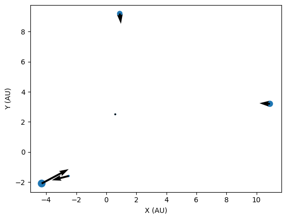

```python
def plotParticles2WithQuivers(masses, positions, forces):
    xPositions = []
    yPositions = []
    xForces = []
    yForces = []
    for i in range(len(masses)):
        xPositions.append(positions[i][0]/au)
        yPositions.append(positions[i][1]/au)
        xForces.append(forces[i][0])
        yForces.append(forces[i][1])

    areaForSymbol = masses/np.max(masses)*100
    plt.scatter(xPositions,yPositions, s=areaForSymbol)
    plt.quiver(xPositions,yPositions,xForces,yForces)

    plt.axis('scaled')
    plt.xlabel('X (AU)')
    plt.ylabel('Y (AU)')

plotParticles2WithQuivers(masses, positions, forces)
```

```python
print(f"forces, {len(forces)} {type(forces)}")
print(f"positions, {len(positions)} {type(positions)}")
print(len(forces) == len(positions))

#testing to make sure I can accsses each particels position and each force
for i in range(len(forces)):
    print(f"\n index = {i} particle = {positions[i]} force =  {forces[i]}")
```

```
forces, 5 <class 'list'>
positions, 5 <class 'list'>
True

 index = 0 particle = [8.976e+10 3.740e+11 5.984e+09] force =  [-4.11343427e+15 -2.15614139e+15  9.90522230e+14]

 index = 1 particle = [1.34640e+11 1.37632e+12 1.79520e+10] force =  [ 6.12126538e+15 -5.34319947e+16  1.77549137e+15]

 index = 2 particle = [-6.4328e+11 -3.1416e+11  1.2716e+11] force =  [ 1.40608183e+17  7.47025316e+16 -6.88057387e+16]

 index = 3 particle = [1.63064e+12 4.78720e+11 0.00000e+00] force =  [-5.45556893e+16  2.97690767e+15  1.79960353e+15]

 index = 4 particle = [-3.7400e+11 -2.3936e+11 -6.2832e+10] force =  [-8.80603249e+16 -2.20913032e+16  6.42401215e+16]
```

Ok, so using a few of the functions from homework D, I can calculate a list of 3-dimensional force vectors from a list of 3-dimensional positions, a list of masses and a list of separations.

## 2 leapfrog integrator

#### Leapfrog integratioon formula

$$ r_{i}(t+\Delta t) = r_{i}(t)+v_{i}(t)(\Delta t)+ 1/2a_{i}(t)(\Delta t)^2$$ $$ v_{i}(t+\Delta t) = v_{i}(t)+1/2[a_{i}(t)+a_{i}(t+\Delta t)](\Delta t)$$ $$ a_{i}(t+\Delta t) = \frac{F_{i}(t+\Delta t)}{m_{i}} $$

```python
#leapfrog function
def leapfrogStep(r_i, v_i, F, masses, delta_t, display):
    '''
    Calculate the position of a particle
    given the force, initial position r_i,
    initial velocity, Force on the particle and
    the time step between start_t and end_t

    -----inputs-----------------

    *All inputs are for the same one spatial dimension

    r_i: float or integer
    The initial position of the particle in one dimension
    r_i has units of meters

    v_i: float or integer
    The initial velocity of the particle in one dimension
    v_i has units of meters per second

    a_i: float or integer
    The initial acceleration of the particle in one dimension
    a_i has units of meters per second squared

    F: function
    a function that describes the force at every time interval for the particle in one dimension
    f has units of newtons

    display: boolean
    the display boolean will tell if the function should print the values or just return them

    -------------function------------

    the leapstep function calculates the new velocities for one delta time

    -----output-------------

    The lestep function outputs


    '''
    #assigning all of the inputs in the functions as variables insiee the function





    a_i = F(masses, r_i) #my function returns the acceleration

    r_i = np.array(r_i)

    v_i = np.array(v_i)

    r_t = r_i+v_i*delta_t+1/2*(a_i)*delta_t**2

    a_t = F( masses, r_t) #my function returns the acceleration

    v_t = v_i+1/2*(a_i + a_t)*delta_t

    if display == True:
        print(f" a = {a_t} v = {v_t} r = {r_t}")
        return( a_t, v_t, r_t)
    else:
        return( a_t, v_t, r_t)



    current_t += delta_t #incrementing current_t by delta_t
```

```python
print(masses)
```

```
[2e+24, 3e+25, 6.5e+25, 4e+25, 3e+24]
```

```python
r_i = 0
v_i = 1
a_i = 0
m_i = 1
delta_t = 1
current_t = 1
display = True
forces = force

leapfrogStep(r_i, v_i, forces, m_i, delta_t, display)
```

[output not shown]

Please note that this is the first version of my leapfrog integrator, and I still need to work out taking in the masses and calling the calculateForceVectors function to calculate the force

```python
def force(masses, positions): # defining the graviational potential force between two positions
    #print(masses)
    #print(type(masses))
    forces = netForces(masses,positions)
    #print(forces)
    #print(len(masses))
    #print(len(forces[0]))
    accelerations = []


    acceleration = []
    count = 0
    for i in range(len(forces)):

        #print(f"\n")
        local = []

        for j in range(len(forces[i])):


            local.append(forces[i][j]/masses[i])
            count +=1
        acceleration.append(local)

    accel_numpy = np.array(acceleration)
    #print(accel_numpy)
    #print("force function ran")

    return accel_numpy
```

#### fixed leapfrogStep function with netforce function

```python
list = [[0,0,0],[0,0,0],[0,0,0],[0,0,0],[0,0,0]]
v_i = np.array(list)
F = force
r_i = positions
masses = masses
delta_t = 1
display = False

a_t, v_t, r_t = leapfrogStep(r_i, v_i, F, masses, delta_t, display)

print(f"a_t is the acceleration in three dimensions of the five particles and have values: \n \n {a_t} \n")
print(f"v_t is the velocity in three dimensions of the five particles and have values: \n \n {v_t} \n")
print(f"r_t is the position in three dimensions of the five particles and have values: \n \n {r_t} \n")
```

```
a_t is the acceleration in three dimensions of the five particles and have values:

 [[-2.05671713e-09 -1.07807069e-09  4.95261115e-10]
 [ 2.04042179e-10 -1.78106649e-09  5.91830458e-11]
 [ 2.16320282e-09  1.14926972e-09 -1.05854983e-09]
 [-1.36389223e-09  7.44226918e-11  4.49900882e-11]
 [-2.93534416e-08 -7.36376775e-09  2.14133738e-08]]

v_t is the velocity in three dimensions of the five particles and have values:

 [[-2.05671713e-09 -1.07807069e-09  4.95261115e-10]
 [ 2.04042179e-10 -1.78106649e-09  5.91830458e-11]
 [ 2.16320282e-09  1.14926972e-09 -1.05854983e-09]
 [-1.36389223e-09  7.44226918e-11  4.49900882e-11]
 [-2.93534416e-08 -7.36376775e-09  2.14133738e-08]]

r_t is the position in three dimensions of the five particles and have values:

 [[ 8.97600000e+10  3.74000000e+11  5.98400000e+09]
 [ 1.34640000e+11  1.37632000e+12  1.79520000e+10]
 [-6.43280000e+11 -3.14160000e+11  1.27160000e+11]
 [ 1.63064000e+12  4.78720000e+11  2.24950441e-11]
 [-3.74000000e+11 -2.39360000e+11 -6.28320000e+10]]
```

```python
#testing my function with the earth and me
list = [[0,0,0],[0,0,0]]
v_i = np.array(list)
F = force
earth_center = np.array([ 0,  0,  0])
luca_position = np.array([ 0,  6378137,  0]) #the equatorial radius of Earth is 6378.137 km from NASA Earth Fact Sheet: https://nssdc.gsfc.nasa.gov/planetary/factsheet/earthfact.html
r_i = [earth_center, luca_position]
earth_mass = 5.9722e24 #mass of Earth is also from NASA EarthFact Sheet
luca_mass = 7e1
masses = [earth_mass, luca_mass]
delta_t = 1
display = False

a_t, v_t, r_t = leapfrogStep(r_i, v_i, F, masses, delta_t, display)

print(f"a_t is the acceleration in three dimensions of the Earth and me are: \n \n {a_t} \n")
print(f"v_t is the velocity in three dimensions of the Earth and me are: \n \n {v_t} \n")
print(f"r_t is the position in three dimensions of the Earth and me are: \n \n {r_t} \n")
```

```
a_t is the acceleration in three dimensions of the Earth and me are:

 [[ 0.00000000e+00  1.14772239e-22  0.00000000e+00]
 [ 0.00000000e+00 -9.79203950e+00  0.00000000e+00]]

v_t is the velocity in three dimensions of the Earth and me are:

 [[ 0.00000000e+00  1.14772151e-22  0.00000000e+00]
 [ 0.00000000e+00 -9.79203199e+00  0.00000000e+00]]

r_t is the position in three dimensions of the Earth and me are:

 [[0.00000000e+00 5.73860314e-23 0.00000000e+00]
 [0.00000000e+00 6.37813210e+06 0.00000000e+00]]
```

## 3 Write a function called calculateTrajectories

For this, I will simply rewrite the for loop in my current leapfrogStep function to remove it. I will then rewrite that for loop into a function called calculateTrajectories. The calculateTrajectories function will have the outputs:

```
1 times (1D array, with elements identifying each time step)
2 positions at all times (multi-dimensional array or arrays)
3 velocities at all times (multi-dimensional array or arrays)
```

Your returned times, positions, and velocities arrays should all contain your initial time (t=0), positions, and velocities as well.

```python
#leapfrog function
def calculateTrajectories(r_i, v_i, F, masses, delta_t, start_t, end_t, display):
    '''
    Calculate the position of a particle
    given the force, initial position r_i,
    initial velocity, Force on the particle and
    the time step between start_t and end_t

    -----inputs-----------------

    *All inputs are for the same one spatial dimension

    r_i: a list of the initial positions of the particles
    r_i has units of meters

    v_i: a list of the initial velocities of the particles
    v_i has units of meters per second


    F: function
    a function that describes the force at every time interval for the particle in one dimension
    f has units of newtons

    delta_t: flaot
    The time increment you would like to subdivide the time period from start_time to end_time in

    start_t: float
    The time you would like to start calculating the trajectory of the particle at

    end_t: float
    The time you would like to end calculating the trajectory of the particle at

    display: boolean
    The display boolean will tell if the function should print the values or just return them


    -----------what the function actualy does---------------

    The calculateTrajectories function will use the leapfrogStep function to calculate the
    position, veelcoty and acceleration of each particle at each time, then add it to a list

    -----------output----------------

    if display == True then the function will print all of the positions, velocities, and accelerations in a
    nice f string

    if display == false then the function will just return the lists for position, velocity, and acceleration


    '''
    #assigning all of the inputs in the functions as variables insiee the function


    # making four global lists to store the times, positions, velocities and accelerations
    #print(type(F))
    global position
    position = [r_i]
    global velocity
    velocity = [v_i]
    global acceleration
    acceleration = [[[0,0,0], [0,0,0]]]
    masses = np.array(masses)
    r_i = np.array(r_i)



    global time
    time = [start_t]



    current_t = start_t
    v_t = v_i #setting the first veloecity v_t as the inital velovity v_i
    if display == True:
        while current_t <= end_t: #looping through all t including end_t
            if current_t == start_t:

                a_t, v_t, r_t = leapfrogStep(r_i, v_i, F, masses, delta_t, display)
                current_t += delta_t #incrementing current_t by delta_t
                position.append(r_t)
                velocity.append(v_t)
                acceleration.append(a_t)
                time.append(current_t)
            else:
                a_t, v_t, r_t = leapfrogStep(r_t, v_t, F, masses, delta_t, display)
                current_t += delta_t #incrementing current_t by delta_t
                position.append(r_t)
                velocity.append(v_t)
                acceleration.append(a_t)
                time.append(current_t)

        print(f"the final position is, {position[-1]}, the final velocity is, {v_t} meters/seocnd")

    else:
        while current_t <= end_t: #looping through all t including end_t

            if current_t == start_t:
                a_t, v_t, r_t = leapfrogStep(r_i, v_i, F, masses, delta_t, display)
                current_t += delta_t #incrementing current_t by delta_t
                position.append(r_t)
                velocity.append(v_t)
                acceleration.append(a_t)
                time.append(current_t)
            else:
                a_t, v_t, r_t = leapfrogStep(r_t, v_t, F, masses, delta_t, display)
                current_t += delta_t #incrementing current_t by delta_t
                position.append(r_t)
                velocity.append(v_t)
                acceleration.append(a_t)
                time.append(current_t)
```

```python
#testing the calculateTrajectories function with display == True
earth_center = np.array([ 0,  0,  0])
luca_position = np.array([ 0,  6378137,  0]) #the equatorial radius of Earth is 6378.137 km from NASA Earth Fact Sheet: https://nssdc.gsfc.nasa.gov/planetary/factsheet/earthfact.html
r_i = [earth_center, luca_position]

list = [[0,0,0],[0,0,0]]
v_i = np.array(list)

earth_mass = 5.9722e24 #mass of Earth is also from NASA EarthFact Sheet
luca_mass = 7e1
masses = [earth_mass, luca_mass]
delta_t = 1
start_t = 0
end_t = 10
display == True

calculateTrajectories(r_i, v_i, force, masses, delta_t, start_t, end_t, display)
print(f" acceleration = {type(acceleration)} with length, {len(acceleration)} with elements, {acceleration}")
print(f" velocity = {type(velocity)} with length, {len(velocity)} with elements, {velocity}")
print(f" position = {type(position)} with length, {len(position)} with elements, {position}")
print(f" time = {type(time)} with length, {len(time)} with elements, {time}")
```

```
 acceleration = <class 'list'> with length, 12 with elements, [[[0, 0, 0], [0, 0, 0]], array([[ 0.00000000e+00,  1.14772239e-22,  0.00000000e+00],
       [ 0.00000000e+00, -9.79203950e+00,  0.00000000e+00]]), array([[ 0.00000000e+00,  1.14772768e-22,  0.00000000e+00],
       [ 0.00000000e+00, -9.79208460e+00,  0.00000000e+00]]), array([[ 0.00000000e+00,  1.14773649e-22,  0.00000000e+00],
       [ 0.00000000e+00, -9.79215977e+00,  0.00000000e+00]]), array([[ 0.00000000e+00,  1.14774882e-22,  0.00000000e+00],
       [ 0.00000000e+00, -9.79226501e+00,  0.00000000e+00]]), array([[ 0.00000000e+00,  1.14776468e-22,  0.00000000e+00],
       [ 0.00000000e+00, -9.79240031e+00,  0.00000000e+00]]), array([[ 0.00000000e+00,  1.14778406e-22,  0.00000000e+00],
       [ 0.00000000e+00, -9.79256569e+00,  0.00000000e+00]]), array([[ 0.00000000e+00,  1.14780697e-22,  0.00000000e+00],
       [ 0.00000000e+00, -9.79276115e+00,  0.00000000e+00]]), array([[ 0.00000000e+00,  1.14783341e-22,  0.00000000e+00],
       [ 0.00000000e+00, -9.79298668e+00,  0.00000000e+00]]), array([[ 0.00000000e+00,  1.14786337e-22,  0.00000000e+00],
       [ 0.00000000e+00, -9.79324230e+00,  0.00000000e+00]]), array([[ 0.00000000e+00,  1.14789686e-22,  0.00000000e+00],
       [ 0.00000000e+00, -9.79352800e+00,  0.00000000e+00]]), array([[ 0.00000000e+00,  1.14793387e-22,  0.00000000e+00],
       [ 0.00000000e+00, -9.79384380e+00,  0.00000000e+00]])]
 velocity = <class 'list'> with length, 12 with elements, [array([[0, 0, 0],
       [0, 0, 0]]), array([[ 0.00000000e+00,  1.14772151e-22,  0.00000000e+00],
       [ 0.00000000e+00, -9.79203199e+00,  0.00000000e+00]]), array([[ 0.00000000e+00,  2.29544654e-22,  0.00000000e+00],
       [ 0.00000000e+00, -1.95840940e+01,  0.00000000e+00]]), array([[ 0.00000000e+00,  3.44317862e-22,  0.00000000e+00],
       [ 0.00000000e+00, -2.93762162e+01,  0.00000000e+00]]), array([[ 0.00000000e+00,  4.59092127e-22,  0.00000000e+00],
       [ 0.00000000e+00, -3.91684286e+01,  0.00000000e+00]]), array([[ 0.00000000e+00,  5.73867802e-22,  0.00000000e+00],
       [ 0.00000000e+00, -4.89607613e+01,  0.00000000e+00]]), array([[ 0.00000000e+00,  6.88645240e-22,  0.00000000e+00],
       [ 0.00000000e+00, -5.87532443e+01,  0.00000000e+00]]), array([[ 0.00000000e+00,  8.03424791e-22,  0.00000000e+00],
       [ 0.00000000e+00, -6.85459077e+01,  0.00000000e+00]]), array([[ 0.00000000e+00,  9.18206810e-22,  0.00000000e+00],
       [ 0.00000000e+00, -7.83387816e+01,  0.00000000e+00]]), array([[ 0.00000000e+00,  1.03299165e-21,  0.00000000e+00],
       [ 0.00000000e+00, -8.81318961e+01,  0.00000000e+00]]), array([[ 0.00000000e+00,  1.14777966e-21,  0.00000000e+00],
       [ 0.00000000e+00, -9.79252812e+01,  0.00000000e+00]]), array([[ 0.00000000e+00,  1.26257120e-21,  0.00000000e+00],
       [ 0.00000000e+00, -1.07718967e+02,  0.00000000e+00]])]
 position = <class 'list'> with length, 12 with elements, [[array([0, 0, 0]), array([      0, 6378137,       0])], array([[0.00000000e+00, 5.73860314e-23, 0.00000000e+00],
       [0.00000000e+00, 6.37813210e+06, 0.00000000e+00]]), array([[0.00000000e+00, 2.29544302e-22, 0.00000000e+00],
       [0.00000000e+00, 6.37811742e+06, 0.00000000e+00]]), array([[0.00000000e+00, 5.16475339e-22, 0.00000000e+00],
       [0.00000000e+00, 6.37809294e+06, 0.00000000e+00]]), array([[0.00000000e+00, 9.18180026e-22, 0.00000000e+00],
       [0.00000000e+00, 6.37805866e+06, 0.00000000e+00]]), array([[0.00000000e+00, 1.43465959e-21, 0.00000000e+00],
       [0.00000000e+00, 6.37801460e+06, 0.00000000e+00]]), array([[0.00000000e+00, 2.06591563e-21, 0.00000000e+00],
       [0.00000000e+00, 6.37796074e+06, 0.00000000e+00]]), array([[0.00000000e+00, 2.81195007e-21, 0.00000000e+00],
       [0.00000000e+00, 6.37789709e+06, 0.00000000e+00]]), array([[0.00000000e+00, 3.67276521e-21, 0.00000000e+00],
       [0.00000000e+00, 6.37782365e+06, 0.00000000e+00]]), array([[0.00000000e+00, 4.64836369e-21, 0.00000000e+00],
       [0.00000000e+00, 6.37774041e+06, 0.00000000e+00]]), array([[0.00000000e+00, 5.73874851e-21, 0.00000000e+00],
       [0.00000000e+00, 6.37764739e+06, 0.00000000e+00]]), array([[0.00000000e+00, 6.94392301e-21, 0.00000000e+00],
       [0.00000000e+00, 6.37754456e+06, 0.00000000e+00]])]
 time = <class 'list'> with length, 12 with elements, [0, 1, 2, 3, 4, 5, 6, 7, 8, 9, 10, 11]
```

my calculateTrajectories function seems to be working with the test case of me falling towards the center of mass of the Earth.. My acceleration stayed relatively constant which makes sense for the time scale of 11 seconds

my acceleration started at -9.79203950e+00 m/s/s at time = 0 and ended at -9.79384380e+00 m/s/s at time = 11 However, it did increase in magnitude as time increased because I was getting closer to the center of the Earth This shows that I am successfully calling my force(masses, positions) function

Finally, my position started at [ 0, 6378137, 0] at time = 0 my position ended at [0.00000000e+00, 6.37754456e+06, 0.00000000e+00] at time = 11 This demonstrates again that both my leapfrogStep and my calculateTrajectories function are working correctly, as my ending position has a smaller y-value than my starting position, as I am moving towards the center of mass of the Earth.

```python
#testing the calculateTrajectories function with display == False
r_i = [[0,0,0], [10,10,20],[40,30,70]]
v_i = [[1,1,1],[4,5,6],[2,3,4]]

m_i = [10,20,10]
delta_t = 1
start_t = 5
end_t = 10
display = True

calculateTrajectories(r_i, v_i, force, m_i, delta_t, start_t, end_t, display)
print(f" acceleration = {type(acceleration)} with length, {len(acceleration)} with elements, {acceleration}")
print(f" velocity = {type(velocity)} with length, {len(velocity)} with elements, {velocity}")
print(f" position = {type(position)} with length, {len(position)} with elements, {position}")
print(f" time = {type(time)} with length, {len(time)} with elements, {time}")
```

```
 a = [[ 5.94708502e-13  6.29197813e-13  1.13825520e-12]
 [-1.84659499e-13 -2.39538933e-13 -3.74679542e-13]
 [-2.25389504e-13 -1.50119947e-13 -3.88896113e-13]] v = [[1. 1. 1.]
 [4. 5. 6.]
 [2. 3. 4.]] r = [[ 1.  1.  1.]
 [14. 15. 26.]
 [42. 33. 74.]]
 a = [[ 4.09418049e-13  4.49696914e-13  7.65396912e-13]
 [-8.43792817e-14 -1.47446033e-13 -1.69111394e-13]
 [-2.40659486e-13 -1.54804848e-13 -4.27174124e-13]] v = [[1. 1. 1.]
 [4. 5. 6.]
 [2. 3. 4.]] r = [[ 2.  2.  2.]
 [18. 20. 32.]
 [44. 36. 78.]]
 a = [[ 3.00665774e-13  3.38024625e-13  5.53703583e-13]
 [-2.09661858e-14 -8.95446707e-14 -3.96183798e-14]
 [-2.58733403e-13 -1.58935283e-13 -4.74466823e-13]] v = [[1. 1. 1.]
 [4. 5. 6.]
 [2. 3. 4.]] r = [[ 3.  3.  3.]
 [22. 25. 38.]
 [46. 39. 82.]]
 a = [[ 2.31298092e-13  2.64158093e-13  4.21855443e-13]
 [ 2.42305188e-14 -5.11840028e-14  5.54583559e-14]
 [-2.79759130e-13 -1.61790087e-13 -5.32772155e-13]] v = [[1. 1. 1.]
 [4. 5. 6.]
 [2. 3. 4.]] r = [[ 4.  4.  4.]
 [26. 30. 44.]
 [48. 42. 86.]]
 a = [[ 1.84229440e-13  2.12812870e-13  3.33973695e-13]
 [ 5.97845471e-14 -2.52927654e-14  1.35336248e-13]
 [-3.03798534e-13 -1.62227340e-13 -6.04646191e-13]] v = [[1. 1. 1.]
 [4. 5. 6.]
 [2. 3. 4.]] r = [[ 5.  5.  5.]
 [30. 35. 50.]
 [50. 45. 90.]]
 a = [[ 1.50734521e-13  1.75659706e-13  2.72286085e-13]
 [ 8.99861537e-14 -8.60328138e-15  2.10511823e-13]
 [-3.30706829e-13 -1.58453143e-13 -6.93309731e-13]] v = [[1. 1. 1.]
 [4. 5. 6.]
 [2. 3. 4.]] r = [[ 6.  6.  6.]
```

[output cut: 32 more lines]

```
       [2., 3., 4.]])]
 position = <class 'list'> with length, 7 with elements, [[[0, 0, 0], [10, 10, 20], [40, 30, 70]], array([[ 1.,  1.,  1.],
       [14., 15., 26.],
       [42., 33., 74.]]), array([[ 2.,  2.,  2.],
       [18., 20., 32.],
       [44., 36., 78.]]), array([[ 3.,  3.,  3.],
       [22., 25., 38.],
       [46., 39., 82.]]), array([[ 4.,  4.,  4.],
       [26., 30., 44.],
       [48., 42., 86.]]), array([[ 5.,  5.,  5.],
       [30., 35., 50.],
       [50., 45., 90.]]), array([[ 6.,  6.,  6.],
       [34., 40., 56.],
       [52., 48., 94.]])]
 time = <class 'list'> with length, 7 with elements, [5, 6, 7, 8, 9, 10, 11]
```

```python
m_i = 10 #kg
m_j = 100 #kg
p_i = np.array([0,0,0])
p_j = np.array([1,1,1])



forceVector(m_i, m_j, p_i, p_j)
```

```
array([1.2836421e-08, 1.2836421e-08, 1.2836421e-08])
```

```python
#testing the calculateTrajectories function with the forceVector function and with posiotns, veloctiy and acceleration vectors  arrays in 3 dimensions
r_i = [[0,0,0], [10,10,10]]
v_i = [[0,0,0], [0,0,0]]

m_i = np.array([100,100])
delta_t = 1
start_t = 0
end_t = 2
display = True

p_j = np.array([10,10,10])


calculateTrajectories(r_i, v_i, force, m_i, delta_t, start_t, end_t, display)
print(f" acceleration = {type(acceleration)} with length, {len(acceleration)} with elements, {acceleration}")
print(f" velocity = {type(velocity)} with length, {len(velocity)} with elements, {velocity}")
print(f" position = {type(position)} with length, {len(position)} with elements, {position}")
print(f" time = {type(time)} with length, {len(time)} with elements, {time}")
```

```
 a = [[ 1.2836421e-11  1.2836421e-11  1.2836421e-11]
 [-1.2836421e-11 -1.2836421e-11 -1.2836421e-11]] v = [[ 1.2836421e-11  1.2836421e-11  1.2836421e-11]
 [-1.2836421e-11 -1.2836421e-11 -1.2836421e-11]] r = [[6.41821049e-12 6.41821049e-12 6.41821049e-12]
 [1.00000000e+01 1.00000000e+01 1.00000000e+01]]
 a = [[ 1.2836421e-11  1.2836421e-11  1.2836421e-11]
 [-1.2836421e-11 -1.2836421e-11 -1.2836421e-11]] v = [[ 2.5672842e-11  2.5672842e-11  2.5672842e-11]
 [-2.5672842e-11 -2.5672842e-11 -2.5672842e-11]] r = [[2.5672842e-11 2.5672842e-11 2.5672842e-11]
 [1.0000000e+01 1.0000000e+01 1.0000000e+01]]
 a = [[ 1.2836421e-11  1.2836421e-11  1.2836421e-11]
 [-1.2836421e-11 -1.2836421e-11 -1.2836421e-11]] v = [[ 3.8509263e-11  3.8509263e-11  3.8509263e-11]
 [-3.8509263e-11 -3.8509263e-11 -3.8509263e-11]] r = [[5.77638944e-11 5.77638944e-11 5.77638944e-11]
 [1.00000000e+01 1.00000000e+01 1.00000000e+01]]
the final position is, [[5.77638944e-11 5.77638944e-11 5.77638944e-11]
 [1.00000000e+01 1.00000000e+01 1.00000000e+01]], the final velocity is, [[ 3.8509263e-11  3.8509263e-11  3.8509263e-11]
 [-3.8509263e-11 -3.8509263e-11 -3.8509263e-11]] meters/seocnd
 acceleration = <class 'list'> with length, 4 with elements, [[[0, 0, 0], [0, 0, 0]], array([[ 1.2836421e-11,  1.2836421e-11,  1.2836421e-11],
       [-1.2836421e-11, -1.2836421e-11, -1.2836421e-11]]), array([[ 1.2836421e-11,  1.2836421e-11,  1.2836421e-11],
       [-1.2836421e-11, -1.2836421e-11, -1.2836421e-11]]), array([[ 1.2836421e-11,  1.2836421e-11,  1.2836421e-11],
       [-1.2836421e-11, -1.2836421e-11, -1.2836421e-11]])]
 velocity = <class 'list'> with length, 4 with elements, [[[0, 0, 0], [0, 0, 0]], array([[ 1.2836421e-11,  1.2836421e-11,  1.2836421e-11],
       [-1.2836421e-11, -1.2836421e-11, -1.2836421e-11]]), array([[ 2.5672842e-11,  2.5672842e-11,  2.5672842e-11],
       [-2.5672842e-11, -2.5672842e-11, -2.5672842e-11]]), array([[ 3.8509263e-11,  3.8509263e-11,  3.8509263e-11],
       [-3.8509263e-11, -3.8509263e-11, -3.8509263e-11]])]
 position = <class 'list'> with length, 4 with elements, [[[0, 0, 0], [10, 10, 10]], array([[6.41821049e-12, 6.41821049e-12, 6.41821049e-12],
       [1.00000000e+01, 1.00000000e+01, 1.00000000e+01]]), array([[2.5672842e-11, 2.5672842e-11, 2.5672842e-11],
       [1.0000000e+01, 1.0000000e+01, 1.0000000e+01]]), array([[5.77638944e-11, 5.77638944e-11, 5.77638944e-11],
       [1.00000000e+01, 1.00000000e+01, 1.00000000e+01]])]
 time = <class 'list'> with length, 4 with elements, [0, 1, 2, 3]
```